# Project 1: SAT & ACT Analysis

## Problem Statement

#### * Analyze statewise data and make recommendations with an emphasis on improving the overall SAT participation rates

#### * Identify States and recommend actions to improve SAT participation and Total SAT scores

## Executive Summary

- The Participation rates and Test scores are negatively correlated at state aggregate levels.
- The presentation will focus on improving the SAT participation rates.
- Actionable insights on improving the Test scores will require further granular analysis.

## *All libraries used should be added here*

```python
#Imports the numpy and the pandas libraries:

import numpy as np
import pandas as pd
import seaborn as sns
import matplotlib.pyplot as plt
```

## 2017 Data Import and Cleaning

#### 1. Read In SAT & ACT Data

Read in the `sat_2017.csv` and `act_2017.csv` files and assign them to appropriately named pandas dataframes.

```python
#Code:

# the SAT & ACT data for 2017 is being assigned to the panda dataframes data_sat2017 and data_act2017.
data_sat2017 = pd.read_csv("sat_2017.csv")
data_act2017 = pd.read_csv("act_2017.csv")
```

#### 2. Display Data

Print the structure and the first 10 rows of each dataframe to this jupyter notebook

```python
#Code:

# print the structure of the data_sat2017 data frame and the first 10 rows.
print(data_sat2017.dtypes)
print('\n'*2)
display(data_sat2017.iloc[:10,:])

# print the structure of the data_act2017 data frame and the first 10 rows.
print('\n'*2)
print(data_act2017.dtypes)
print('\n'*2)
display(data_act2017.iloc[:10,:])
```

```
State                                 object
Participation                         object
Evidence-Based Reading and Writing     int64
Math                                   int64
Total                                  int64
dtype: object
```

|  | State | Participation | Evidence-Based Reading and Writing | Math | Total |
| --- | --- | --- | --- | --- | --- |
| 0 | Alabama | 5% | 593 | 572 | 1165 |
| 1 | Alaska | 38% | 547 | 533 | 1080 |
| 2 | Arizona | 30% | 563 | 553 | 1116 |
| 3 | Arkansas | 3% | 614 | 594 | 1208 |
| 4 | California | 53% | 531 | 524 | 1055 |
| 5 | Colorado | 11% | 606 | 595 | 1201 |
| 6 | Connecticut | 100% | 530 | 512 | 1041 |
| 7 | Delaware | 100% | 503 | 492 | 996 |
| 8 | District of Columbia | 100% | 482 | 468 | 950 |
| 9 | Florida | 83% | 520 | 497 | 1017 |

```
State             object
Participation     object
English          float64
Math             float64
Reading          float64
Science          float64
Composite         object
dtype: object
```

|  | State | Participation | English | Math | Reading | Science | Composite |
| --- | --- | --- | --- | --- | --- | --- | --- |
| 0 | National | 60% | 20.3 | 20.7 | 21.4 | 21.0 | 21.0 |
| 1 | Alabama | 100% | 18.9 | 18.4 | 19.7 | 19.4 | 19.2 |
| 2 | Alaska | 65% | 18.7 | 19.8 | 20.4 | 19.9 | 19.8 |
| 3 | Arizona | 62% | 18.6 | 19.8 | 20.1 | 19.8 | 19.7 |
| 4 | Arkansas | 100% | 18.9 | 19.0 | 19.7 | 19.5 | 19.4 |
| 5 | California | 31% | 22.5 | 22.7 | 23.1 | 22.2 | 22.8 |
| 6 | Colorado | 100% | 20.1 | 20.3 | 21.2 | 20.9 | 20.8 |
| 7 | Connecticut | 31% | 25.5 | 24.6 | 25.6 | 24.6 | 25.2 |
| 8 | Delaware | 18% | 24.1 | 23.4 | 24.8 | 23.6 | 24.1 |
| 9 | District of Columbia | 32% | 24.4 | 23.5 | 24.9 | 23.5 | 24.2 |

#### 3. Verbally Describe Data

Take your time looking through the data and thoroughly describe the data in the markdown cell below.

#### Summary:

The data consists of SAT and ACT scores and the test participation for each US state and aggregated at the National level for the year 2017.

#### ACT Tests

The ACT test consists of four compulsory multiple choice subject tests:

- English
- Mathematics
- Reading
- Science reasoning

The main four sections are individually scored on a scale of 1–36, and a composite score (the rounded whole number average of the four sections) is provided.

#### SAT

The SAT test consists of two sections:

- Evidence-Based Reading and Writing
- Math

Section scores are reported on a scale of 200 to 800. A total score for the SAT is calculated by adding the two section scores, resulting in total scores that range from 400 to 1600.

#### 4a. Does the data look complete and are there any other issues?

Answer:

```python
#data_sat2017
display(data_sat2017.describe())
display(data_sat2017)

#data_sat2017
display(data_act2017.describe())
display(data_act2017)
```

|  | Evidence-Based Reading and Writing | Math | Total |
| --- | --- | --- | --- |
| count | 51.000000 | 51.000000 | 51.000000 |
| mean | 569.117647 | 547.627451 | 1126.098039 |
| std | 45.666901 | 84.909119 | 92.494812 |
| min | 482.000000 | 52.000000 | 950.000000 |
| 25% | 533.500000 | 522.000000 | 1055.500000 |
| 50% | 559.000000 | 548.000000 | 1107.000000 |
| 75% | 613.000000 | 599.000000 | 1212.000000 |
| max | 644.000000 | 651.000000 | 1295.000000 |

|  | State | Participation | Evidence-Based Reading and Writing | Math | Total |
| --- | --- | --- | --- | --- | --- |
| 0 | Alabama | 5% | 593 | 572 | 1165 |
| 1 | Alaska | 38% | 547 | 533 | 1080 |
| 2 | Arizona | 30% | 563 | 553 | 1116 |
| 3 | Arkansas | 3% | 614 | 594 | 1208 |
| 4 | California | 53% | 531 | 524 | 1055 |
| 5 | Colorado | 11% | 606 | 595 | 1201 |
| 6 | Connecticut | 100% | 530 | 512 | 1041 |
| 7 | Delaware | 100% | 503 | 492 | 996 |
| 8 | District of Columbia | 100% | 482 | 468 | 950 |
| 9 | Florida | 83% | 520 | 497 | 1017 |
| 10 | Georgia | 61% | 535 | 515 | 1050 |
| 11 | Hawaii | 55% | 544 | 541 | 1085 |
| 12 | Idaho | 93% | 513 | 493 | 1005 |
| 13 | Illinois | 9% | 559 | 556 | 1115 |
| 14 | Indiana | 63% | 542 | 532 | 1074 |
| 15 | Iowa | 2% | 641 | 635 | 1275 |
| 16 | Kansas | 4% | 632 | 628 | 1260 |
| 17 | Kentucky | 4% | 631 | 616 | 1247 |
| 18 | Louisiana | 4% | 611 | 586 | 1198 |
| 19 | Maine | 95% | 513 | 499 | 1012 |
| 20 | Maryland | 69% | 536 | 52 | 1060 |
| 21 | Massachusetts | 76% | 555 | 551 | 1107 |
| 22 | Michigan | 100% | 509 | 495 | 1005 |
| 23 | Minnesota | 3% | 644 | 651 | 1295 |
| 24 | Mississippi | 2% | 634 | 607 | 1242 |
| 25 | Missouri | 3% | 640 | 631 | 1271 |
| 26 | Montana | 10% | 605 | 591 | 1196 |
| 27 | Nebraska | 3% | 629 | 625 | 1253 |
| 28 | Nevada | 26% | 563 | 553 | 1116 |
| 29 | New Hampshire | 96% | 532 | 520 | 1052 |
| 30 | New Jersey | 70% | 530 | 526 | 1056 |
| 31 | New Mexico | 11% | 577 | 561 | 1138 |
| 32 | New York | 67% | 528 | 523 | 1052 |
| 33 | North Carolina | 49% | 546 | 535 | 1081 |
| 34 | North Dakota | 2% | 635 | 621 | 1256 |
| 35 | Ohio | 12% | 578 | 570 | 1149 |
| 36 | Oklahoma | 7% | 530 | 517 | 1047 |
| 37 | Oregon | 43% | 560 | 548 | 1108 |
| 38 | Pennsylvania | 65% | 540 | 531 | 1071 |
| 39 | Rhode Island | 71% | 539 | 524 | 1062 |
| 40 | South Carolina | 50% | 543 | 521 | 1064 |
| 41 | South Dakota | 3% | 612 | 603 | 1216 |
| 42 | Tennessee | 5% | 623 | 604 | 1228 |
| 43 | Texas | 62% | 513 | 507 | 1020 |
| 44 | Utah | 3% | 624 | 614 | 1238 |
| 45 | Vermont | 60% | 562 | 551 | 1114 |
| 46 | Virginia | 65% | 561 | 541 | 1102 |
| 47 | Washington | 64% | 541 | 534 | 1075 |
| 48 | West Virginia | 14% | 558 | 528 | 1086 |
| 49 | Wisconsin | 3% | 642 | 649 | 1291 |
| 50 | Wyoming | 3% | 626 | 604 | 1230 |

|  | English | Math | Reading | Science |
| --- | --- | --- | --- | --- |
| count | 52.000000 | 52.000000 | 52.000000 | 52.000000 |
| mean | 20.919231 | 21.173077 | 22.001923 | 21.040385 |
| std | 2.332132 | 1.963602 | 2.048672 | 3.151113 |
| min | 16.300000 | 18.000000 | 18.100000 | 2.300000 |
| 25% | 19.000000 | 19.400000 | 20.475000 | 19.900000 |
| 50% | 20.550000 | 20.900000 | 21.700000 | 21.150000 |
| 75% | 23.300000 | 23.100000 | 24.125000 | 22.525000 |
| max | 25.500000 | 25.300000 | 26.000000 | 24.900000 |

|  | State | Participation | English | Math | Reading | Science | Composite |
| --- | --- | --- | --- | --- | --- | --- | --- |
| 0 | National | 60% | 20.3 | 20.7 | 21.4 | 21.0 | 21.0 |
| 1 | Alabama | 100% | 18.9 | 18.4 | 19.7 | 19.4 | 19.2 |
| 2 | Alaska | 65% | 18.7 | 19.8 | 20.4 | 19.9 | 19.8 |
| 3 | Arizona | 62% | 18.6 | 19.8 | 20.1 | 19.8 | 19.7 |
| 4 | Arkansas | 100% | 18.9 | 19.0 | 19.7 | 19.5 | 19.4 |
| 5 | California | 31% | 22.5 | 22.7 | 23.1 | 22.2 | 22.8 |
| 6 | Colorado | 100% | 20.1 | 20.3 | 21.2 | 20.9 | 20.8 |
| 7 | Connecticut | 31% | 25.5 | 24.6 | 25.6 | 24.6 | 25.2 |
| 8 | Delaware | 18% | 24.1 | 23.4 | 24.8 | 23.6 | 24.1 |
| 9 | District of Columbia | 32% | 24.4 | 23.5 | 24.9 | 23.5 | 24.2 |
| 10 | Florida | 73% | 19.0 | 19.4 | 21.0 | 19.4 | 19.8 |
| 11 | Georgia | 55% | 21.0 | 20.9 | 22.0 | 21.3 | 21.4 |
| 12 | Hawaii | 90% | 17.8 | 19.2 | 19.2 | 19.3 | 19.0 |
| 13 | Idaho | 38% | 21.9 | 21.8 | 23.0 | 22.1 | 22.3 |
| 14 | Illinois | 93% | 21.0 | 21.2 | 21.6 | 21.3 | 21.4 |
| 15 | Indiana | 35% | 22.0 | 22.4 | 23.2 | 22.3 | 22.6 |
| 16 | Iowa | 67% | 21.2 | 21.3 | 22.6 | 22.1 | 21.9 |
| 17 | Kansas | 73% | 21.1 | 21.3 | 22.3 | 21.7 | 21.7 |
| 18 | Kentucky | 100% | 19.6 | 19.4 | 20.5 | 20.1 | 20.0 |
| 19 | Louisiana | 100% | 19.4 | 18.8 | 19.8 | 19.6 | 19.5 |
| 20 | Maine | 8% | 24.2 | 24.0 | 24.8 | 23.7 | 24.3 |
| 21 | Maryland | 28% | 23.3 | 23.1 | 24.2 | 2.3 | 23.6 |
| 22 | Massachusetts | 29% | 25.4 | 25.3 | 25.9 | 24.7 | 25.4 |
| 23 | Michigan | 29% | 24.1 | 23.7 | 24.5 | 23.8 | 24.1 |
| 24 | Minnesota | 100% | 20.4 | 21.5 | 21.8 | 21.6 | 21.5 |
| 25 | Mississippi | 100% | 18.2 | 18.1 | 18.8 | 18.8 | 18.6 |
| 26 | Missouri | 100% | 19.8 | 19.9 | 20.8 | 20.5 | 20.4 |
| 27 | Montana | 100% | 19.0 | 20.2 | 21.0 | 20.5 | 20.3 |
| 28 | Nebraska | 84% | 20.9 | 20.9 | 21.9 | 21.5 | 21.4 |
| 29 | Nevada | 100% | 16.3 | 18.0 | 18.1 | 18.2 | 17.8 |
| 30 | New Hampshire | 18% | 25.4 | 25.1 | 26.0 | 24.9 | 25.5 |
| 31 | New Jersey | 34% | 23.8 | 23.8 | 24.1 | 23.2 | 23.9 |
| 32 | New Mexico | 66% | 18.6 | 19.4 | 20.4 | 20.0 | 19.7 |
| 33 | New York | 31% | 23.8 | 24.0 | 24.6 | 23.9 | 24.2 |
| 34 | North Carolina | 100% | 17.8 | 19.3 | 19.6 | 19.3 | 19.1 |
| 35 | North Dakota | 98% | 19.0 | 20.4 | 20.5 | 20.6 | 20.3 |
| 36 | Ohio | 75% | 21.2 | 21.6 | 22.5 | 22.0 | 22.0 |
| 37 | Oklahoma | 100% | 18.5 | 18.8 | 20.1 | 19.6 | 19.4 |
| 38 | Oregon | 40% | 21.2 | 21.5 | 22.4 | 21.7 | 21.8 |
| 39 | Pennsylvania | 23% | 23.4 | 23.4 | 24.2 | 23.3 | 23.7 |
| 40 | Rhode Island | 21% | 24.0 | 23.3 | 24.7 | 23.4 | 24.0 |
| 41 | South Carolina | 100% | 17.5 | 18.6 | 19.1 | 18.9 | 18.7 |
| 42 | South Dakota | 80% | 20.7 | 21.5 | 22.3 | 22.0 | 21.8 |
| 43 | Tennessee | 100% | 19.5 | 19.2 | 20.1 | 19.9 | 19.8 |
| 44 | Texas | 45% | 19.5 | 20.7 | 21.1 | 20.9 | 20.7 |
| 45 | Utah | 100% | 19.5 | 19.9 | 20.8 | 20.6 | 20.3 |
| 46 | Vermont | 29% | 23.3 | 23.1 | 24.4 | 23.2 | 23.6 |
| 47 | Virginia | 29% | 23.5 | 23.3 | 24.6 | 23.5 | 23.8 |
| 48 | Washington | 29% | 20.9 | 21.9 | 22.1 | 22.0 | 21.9 |
| 49 | West Virginia | 69% | 20.0 | 19.4 | 21.2 | 20.5 | 20.4 |
| 50 | Wisconsin | 100% | 19.7 | 20.4 | 20.6 | 20.9 | 20.5 |
| 51 | Wyoming | 100% | 19.4 | 19.8 | 20.8 | 20.6 | 20.2x |

#### 4c. Fix any errors you identified

**The data is available** so there's no need to guess or calculate anything. If you didn't find any errors, continue to the next step.

```python
#code
data_sat2017.loc[[20], ['Math']] = 524
data_act2017.loc[[21], ['Science']] = 23.2
data_act2017.loc[[51], ['Composite']] = 20.2
```

#### 5. What are your data types?

Display the data types of each feature.

```python
#code
print("SAT Data Types\n" + str(data_sat2017.dtypes))
print("\n"*2 + "ACT Data Types" + "\n"+ str(data_act2017.dtypes))
```

```
SAT Data Types
State                                 object
Participation                         object
Evidence-Based Reading and Writing     int64
Math                                   int64
Total                                  int64
dtype: object


ACT Data Types
State             object
Participation     object
English          float64
Math             float64
Reading          float64
Science          float64
Composite         object
dtype: object
```

### Summary of the Data Type Review:

1. Apart from **'State'** attribute I expected the **data types** all other variables to be **int64** or **float64**
- However **'Participation'** attribute in both the **data_sat2017** and **data_act2017** are of object data type due to the presence of the **'%'** character.
- In the **'Composite'** attribute in the **data_act2017** dataset the data for **'Wyoming'** had an extra **'x'**

#### 6. Fix Incorrect Data Types

Based on what you discovered above, use appropriate methods to re-type incorrectly typed data.

- Define a function that will allow you to convert participation rates to an appropriate numeric type. Use `map` or `apply` to change these columns in each dataframe.

```python
# A function to change the participation rate in an appropriate numeric type
def change_participationrate_tonumeric(data_year,column_name, numeric_type):

    data_year[[column_name]] = data_year[[column_name]].astype(numeric_type)

    return data_year
```

- Fix any individual values preventing other columns from being the appropriate type.

```python
#Modify the Participation rate data so that the '%' could be removed and the data type could later be changed to float

data_act2017.Participation = data_act2017.Participation.map(lambda cell_value: cell_value.replace('%', ''))
data_sat2017.Participation = data_sat2017.Participation.map(lambda cell_value: cell_value.replace('%', ''))
```

- Finish your data modifications by making sure the columns are now typed appropriately.

```python
#Changing the data type of all the number based columns that currently don't have a numeric data type
data_sat2017 = change_participationrate_tonumeric(data_sat2017,"Participation","float")
data_act2017 = change_participationrate_tonumeric(data_act2017,"Participation","float")
data_act2017 = change_participationrate_tonumeric(data_act2017,"Composite","float")
```

- Display the data types again to confirm they are correct.

```python
#Code:


print("Data Types of data_sat2017 holding the SAT data for 2017")
display(data_sat2017.dtypes)

print("\n" + "Data Types of data_act2017 holding the ACT data for 2017")
display(data_act2017.dtypes)
```

```
Data Types of data_sat2017 holding the SAT data for 2017
```

```
State                                  object
Participation                         float64
Evidence-Based Reading and Writing      int64
Math                                    int64
Total                                   int64
dtype: object
```

```
Data Types of data_act2017 holding the ACT data for 2017
```

```
State             object
Participation    float64
English          float64
Math             float64
Reading          float64
Science          float64
Composite        float64
dtype: object
```

#### 7. Rename Columns

Change the names of the columns to more expressive names so that you can tell the difference the SAT columns and the ACT columns. Your solution should map all column names being changed at once (no repeated singular name-changes). **We will be combining these data with some of the data from 2018, and so you should name columns in an appropriate way**.

**Guidelines**:

- Column names should be all lowercase (you will thank yourself when you start pushing data to SQL later in the course)
- Column names should not contain spaces (underscores will suffice--this allows for using the `df.column_name` method to access columns in addition to `df['column_name']`.
- Column names should be unique and informative (the only feature that we actually share between dataframes is the state).

```python
#code

sat_columnnames = {
        'State':'state',
        'Participation':'sat_participation',
        'Evidence-Based Reading and Writing':'sat_read_write',
        'Math':'sat_math',
        'Total':'sat_total'
    }

act_columnnames = {
        'State':'state',
        'Participation':'act_participation',
        'English':'act_english',
        'Math':'act_math',
        'Reading':'act_reading',
        'Science':'act_science',
        'Composite':'act_composite'
    }

data_sat2017.rename(columns = sat_columnnames, inplace=True)
data_act2017.rename(columns = act_columnnames, inplace=True)
```

#### 8. Data dictionary

| Feature | Type | Dataset(s) | Description |
| --- | --- | --- | --- |
| **state** | object | data_act2017, data_sat2017, data_act2018, data_sat2018, combined_2017, combined_2018, combined_2017_2018 | This is the name of the state |
| **act_participation** | float64 | data_act2017, data_act2018, combined_2017, combined_2018, combined_2017_2018 | The ACT partcipation % for the state |
| **act*_english** | float64 | data_act2017, data_act2018, combined_2017, combined_2018, combined_2017_2018 | The Average ACT English Scores for the state |
| **act_math** | float64 | data_act2017, data_act2018, combined_2017, combined_2018, combined_2017_2018 | The Average ACT Math Scores for the state |
| **act_reading** | float64 | data_act2017, data_act2018, combined_2017, combined_2018, combined_2017_2018 | The Average ACT Reading Scores for the state |
| **act_science** | float64 | data_act2017, data_act2018, combined_2017, combined_2018, combined_2017_2018 | The Average ACT Science Scores for the state |
| **act_composite** | float64 | data_act2017, data_act2018, combined_2017, combined_2018, combined_2017_2018 | The Average ACT Composite Scores for the state |
| **sat_participation** | float64 | data_sat2017, data_sat2018, combined_2017, combined_2018, combined_2017_2018 | The SAT partcipation % for the state |
| **sat_read_write** | int64 | data_sat2017, data_sat2018, combined_2017, combined_2018, combined_2017_2018 | The Average SAT Read and Write Scores for the state |
| **sat_math** | int64 | data_sat2017, data_sat2018, combined_2017, combined_2018, combined_2017_2018 | The Average SAT Math Scores for the state |
| **sat_total** | int64 | data_sat2017, data_sat2018, combined_2017, combined_2018, combined_2017_2018 | The Average SAT Total Scores for the state |
| **year** | int64 | data_act2017, data_sat2017, data_act2018, data_sat2018, combined_2017, combined_2018, combined_2017_2018 | The Year for which the scores are applicable |

```python
#code

data_act2017.drop(data_act2017[data_act2017.state == 'National'].index, inplace = True)

display(data_act2017)
```

|  | state | act_participation | act_english | act_math | act_reading | act_science | act_composite |
| --- | --- | --- | --- | --- | --- | --- | --- |
| 1 | Alabama | 100.0 | 18.9 | 18.4 | 19.7 | 19.4 | 19.2 |
| 2 | Alaska | 65.0 | 18.7 | 19.8 | 20.4 | 19.9 | 19.8 |
| 3 | Arizona | 62.0 | 18.6 | 19.8 | 20.1 | 19.8 | 19.7 |
| 4 | Arkansas | 100.0 | 18.9 | 19.0 | 19.7 | 19.5 | 19.4 |
| 5 | California | 31.0 | 22.5 | 22.7 | 23.1 | 22.2 | 22.8 |
| 6 | Colorado | 100.0 | 20.1 | 20.3 | 21.2 | 20.9 | 20.8 |
| 7 | Connecticut | 31.0 | 25.5 | 24.6 | 25.6 | 24.6 | 25.2 |
| 8 | Delaware | 18.0 | 24.1 | 23.4 | 24.8 | 23.6 | 24.1 |
| 9 | District of Columbia | 32.0 | 24.4 | 23.5 | 24.9 | 23.5 | 24.2 |
| 10 | Florida | 73.0 | 19.0 | 19.4 | 21.0 | 19.4 | 19.8 |
| 11 | Georgia | 55.0 | 21.0 | 20.9 | 22.0 | 21.3 | 21.4 |
| 12 | Hawaii | 90.0 | 17.8 | 19.2 | 19.2 | 19.3 | 19.0 |
| 13 | Idaho | 38.0 | 21.9 | 21.8 | 23.0 | 22.1 | 22.3 |
| 14 | Illinois | 93.0 | 21.0 | 21.2 | 21.6 | 21.3 | 21.4 |
| 15 | Indiana | 35.0 | 22.0 | 22.4 | 23.2 | 22.3 | 22.6 |
| 16 | Iowa | 67.0 | 21.2 | 21.3 | 22.6 | 22.1 | 21.9 |
| 17 | Kansas | 73.0 | 21.1 | 21.3 | 22.3 | 21.7 | 21.7 |
| 18 | Kentucky | 100.0 | 19.6 | 19.4 | 20.5 | 20.1 | 20.0 |
| 19 | Louisiana | 100.0 | 19.4 | 18.8 | 19.8 | 19.6 | 19.5 |
| 20 | Maine | 8.0 | 24.2 | 24.0 | 24.8 | 23.7 | 24.3 |
| 21 | Maryland | 28.0 | 23.3 | 23.1 | 24.2 | 23.2 | 23.6 |
| 22 | Massachusetts | 29.0 | 25.4 | 25.3 | 25.9 | 24.7 | 25.4 |
| 23 | Michigan | 29.0 | 24.1 | 23.7 | 24.5 | 23.8 | 24.1 |
| 24 | Minnesota | 100.0 | 20.4 | 21.5 | 21.8 | 21.6 | 21.5 |
| 25 | Mississippi | 100.0 | 18.2 | 18.1 | 18.8 | 18.8 | 18.6 |
| 26 | Missouri | 100.0 | 19.8 | 19.9 | 20.8 | 20.5 | 20.4 |
| 27 | Montana | 100.0 | 19.0 | 20.2 | 21.0 | 20.5 | 20.3 |
| 28 | Nebraska | 84.0 | 20.9 | 20.9 | 21.9 | 21.5 | 21.4 |
| 29 | Nevada | 100.0 | 16.3 | 18.0 | 18.1 | 18.2 | 17.8 |
| 30 | New Hampshire | 18.0 | 25.4 | 25.1 | 26.0 | 24.9 | 25.5 |
| 31 | New Jersey | 34.0 | 23.8 | 23.8 | 24.1 | 23.2 | 23.9 |
| 32 | New Mexico | 66.0 | 18.6 | 19.4 | 20.4 | 20.0 | 19.7 |
| 33 | New York | 31.0 | 23.8 | 24.0 | 24.6 | 23.9 | 24.2 |
| 34 | North Carolina | 100.0 | 17.8 | 19.3 | 19.6 | 19.3 | 19.1 |
| 35 | North Dakota | 98.0 | 19.0 | 20.4 | 20.5 | 20.6 | 20.3 |
| 36 | Ohio | 75.0 | 21.2 | 21.6 | 22.5 | 22.0 | 22.0 |
| 37 | Oklahoma | 100.0 | 18.5 | 18.8 | 20.1 | 19.6 | 19.4 |
| 38 | Oregon | 40.0 | 21.2 | 21.5 | 22.4 | 21.7 | 21.8 |
| 39 | Pennsylvania | 23.0 | 23.4 | 23.4 | 24.2 | 23.3 | 23.7 |
| 40 | Rhode Island | 21.0 | 24.0 | 23.3 | 24.7 | 23.4 | 24.0 |
| 41 | South Carolina | 100.0 | 17.5 | 18.6 | 19.1 | 18.9 | 18.7 |
| 42 | South Dakota | 80.0 | 20.7 | 21.5 | 22.3 | 22.0 | 21.8 |
| 43 | Tennessee | 100.0 | 19.5 | 19.2 | 20.1 | 19.9 | 19.8 |
| 44 | Texas | 45.0 | 19.5 | 20.7 | 21.1 | 20.9 | 20.7 |
| 45 | Utah | 100.0 | 19.5 | 19.9 | 20.8 | 20.6 | 20.3 |
| 46 | Vermont | 29.0 | 23.3 | 23.1 | 24.4 | 23.2 | 23.6 |
| 47 | Virginia | 29.0 | 23.5 | 23.3 | 24.6 | 23.5 | 23.8 |
| 48 | Washington | 29.0 | 20.9 | 21.9 | 22.1 | 22.0 | 21.9 |
| 49 | West Virginia | 69.0 | 20.0 | 19.4 | 21.2 | 20.5 | 20.4 |
| 50 | Wisconsin | 100.0 | 19.7 | 20.4 | 20.6 | 20.9 | 20.5 |
| 51 | Wyoming | 100.0 | 19.4 | 19.8 | 20.8 | 20.6 | 20.2 |

#### 10. Merge Dataframes

Join the 2017 ACT and SAT dataframes using the state in each dataframe as the key and assign this to a new single variable for the whole year.

```python
#Code:

combined_2017 = pd.merge(data_act2017, data_sat2017, on='state', how='inner')
combined_2017.loc[:,"year"] =2017
display(combined_2017.dtypes)
display(combined_2017)
```

```
state                 object
act_participation    float64
act_english          float64
act_math             float64
act_reading          float64
act_science          float64
act_composite        float64
sat_participation    float64
sat_read_write         int64
sat_math               int64
sat_total              int64
year                   int64
dtype: object
```

|  | state | act_participation | act_english | act_math | act_reading | act_science | act_composite | sat_participation | sat_read_write | sat_math | sat_total | year |
| --- | --- | --- | --- | --- | --- | --- | --- | --- | --- | --- | --- | --- |
| 0 | Alabama | 100.0 | 18.9 | 18.4 | 19.7 | 19.4 | 19.2 | 5.0 | 593 | 572 | 1165 | 2017 |
| 1 | Alaska | 65.0 | 18.7 | 19.8 | 20.4 | 19.9 | 19.8 | 38.0 | 547 | 533 | 1080 | 2017 |
| 2 | Arizona | 62.0 | 18.6 | 19.8 | 20.1 | 19.8 | 19.7 | 30.0 | 563 | 553 | 1116 | 2017 |
| 3 | Arkansas | 100.0 | 18.9 | 19.0 | 19.7 | 19.5 | 19.4 | 3.0 | 614 | 594 | 1208 | 2017 |
| 4 | California | 31.0 | 22.5 | 22.7 | 23.1 | 22.2 | 22.8 | 53.0 | 531 | 524 | 1055 | 2017 |
| 5 | Colorado | 100.0 | 20.1 | 20.3 | 21.2 | 20.9 | 20.8 | 11.0 | 606 | 595 | 1201 | 2017 |
| 6 | Connecticut | 31.0 | 25.5 | 24.6 | 25.6 | 24.6 | 25.2 | 100.0 | 530 | 512 | 1041 | 2017 |
| 7 | Delaware | 18.0 | 24.1 | 23.4 | 24.8 | 23.6 | 24.1 | 100.0 | 503 | 492 | 996 | 2017 |
| 8 | District of Columbia | 32.0 | 24.4 | 23.5 | 24.9 | 23.5 | 24.2 | 100.0 | 482 | 468 | 950 | 2017 |
| 9 | Florida | 73.0 | 19.0 | 19.4 | 21.0 | 19.4 | 19.8 | 83.0 | 520 | 497 | 1017 | 2017 |
| 10 | Georgia | 55.0 | 21.0 | 20.9 | 22.0 | 21.3 | 21.4 | 61.0 | 535 | 515 | 1050 | 2017 |
| 11 | Hawaii | 90.0 | 17.8 | 19.2 | 19.2 | 19.3 | 19.0 | 55.0 | 544 | 541 | 1085 | 2017 |
| 12 | Idaho | 38.0 | 21.9 | 21.8 | 23.0 | 22.1 | 22.3 | 93.0 | 513 | 493 | 1005 | 2017 |
| 13 | Illinois | 93.0 | 21.0 | 21.2 | 21.6 | 21.3 | 21.4 | 9.0 | 559 | 556 | 1115 | 2017 |
| 14 | Indiana | 35.0 | 22.0 | 22.4 | 23.2 | 22.3 | 22.6 | 63.0 | 542 | 532 | 1074 | 2017 |
| 15 | Iowa | 67.0 | 21.2 | 21.3 | 22.6 | 22.1 | 21.9 | 2.0 | 641 | 635 | 1275 | 2017 |
| 16 | Kansas | 73.0 | 21.1 | 21.3 | 22.3 | 21.7 | 21.7 | 4.0 | 632 | 628 | 1260 | 2017 |
| 17 | Kentucky | 100.0 | 19.6 | 19.4 | 20.5 | 20.1 | 20.0 | 4.0 | 631 | 616 | 1247 | 2017 |
| 18 | Louisiana | 100.0 | 19.4 | 18.8 | 19.8 | 19.6 | 19.5 | 4.0 | 611 | 586 | 1198 | 2017 |
| 19 | Maine | 8.0 | 24.2 | 24.0 | 24.8 | 23.7 | 24.3 | 95.0 | 513 | 499 | 1012 | 2017 |
| 20 | Maryland | 28.0 | 23.3 | 23.1 | 24.2 | 23.2 | 23.6 | 69.0 | 536 | 524 | 1060 | 2017 |
| 21 | Massachusetts | 29.0 | 25.4 | 25.3 | 25.9 | 24.7 | 25.4 | 76.0 | 555 | 551 | 1107 | 2017 |
| 22 | Michigan | 29.0 | 24.1 | 23.7 | 24.5 | 23.8 | 24.1 | 100.0 | 509 | 495 | 1005 | 2017 |
| 23 | Minnesota | 100.0 | 20.4 | 21.5 | 21.8 | 21.6 | 21.5 | 3.0 | 644 | 651 | 1295 | 2017 |
| 24 | Mississippi | 100.0 | 18.2 | 18.1 | 18.8 | 18.8 | 18.6 | 2.0 | 634 | 607 | 1242 | 2017 |
| 25 | Missouri | 100.0 | 19.8 | 19.9 | 20.8 | 20.5 | 20.4 | 3.0 | 640 | 631 | 1271 | 2017 |
| 26 | Montana | 100.0 | 19.0 | 20.2 | 21.0 | 20.5 | 20.3 | 10.0 | 605 | 591 | 1196 | 2017 |
| 27 | Nebraska | 84.0 | 20.9 | 20.9 | 21.9 | 21.5 | 21.4 | 3.0 | 629 | 625 | 1253 | 2017 |
| 28 | Nevada | 100.0 | 16.3 | 18.0 | 18.1 | 18.2 | 17.8 | 26.0 | 563 | 553 | 1116 | 2017 |
| 29 | New Hampshire | 18.0 | 25.4 | 25.1 | 26.0 | 24.9 | 25.5 | 96.0 | 532 | 520 | 1052 | 2017 |
| 30 | New Jersey | 34.0 | 23.8 | 23.8 | 24.1 | 23.2 | 23.9 | 70.0 | 530 | 526 | 1056 | 2017 |
| 31 | New Mexico | 66.0 | 18.6 | 19.4 | 20.4 | 20.0 | 19.7 | 11.0 | 577 | 561 | 1138 | 2017 |
| 32 | New York | 31.0 | 23.8 | 24.0 | 24.6 | 23.9 | 24.2 | 67.0 | 528 | 523 | 1052 | 2017 |
| 33 | North Carolina | 100.0 | 17.8 | 19.3 | 19.6 | 19.3 | 19.1 | 49.0 | 546 | 535 | 1081 | 2017 |
| 34 | North Dakota | 98.0 | 19.0 | 20.4 | 20.5 | 20.6 | 20.3 | 2.0 | 635 | 621 | 1256 | 2017 |
| 35 | Ohio | 75.0 | 21.2 | 21.6 | 22.5 | 22.0 | 22.0 | 12.0 | 578 | 570 | 1149 | 2017 |
| 36 | Oklahoma | 100.0 | 18.5 | 18.8 | 20.1 | 19.6 | 19.4 | 7.0 | 530 | 517 | 1047 | 2017 |
| 37 | Oregon | 40.0 | 21.2 | 21.5 | 22.4 | 21.7 | 21.8 | 43.0 | 560 | 548 | 1108 | 2017 |
| 38 | Pennsylvania | 23.0 | 23.4 | 23.4 | 24.2 | 23.3 | 23.7 | 65.0 | 540 | 531 | 1071 | 2017 |
| 39 | Rhode Island | 21.0 | 24.0 | 23.3 | 24.7 | 23.4 | 24.0 | 71.0 | 539 | 524 | 1062 | 2017 |
| 40 | South Carolina | 100.0 | 17.5 | 18.6 | 19.1 | 18.9 | 18.7 | 50.0 | 543 | 521 | 1064 | 2017 |
| 41 | South Dakota | 80.0 | 20.7 | 21.5 | 22.3 | 22.0 | 21.8 | 3.0 | 612 | 603 | 1216 | 2017 |
| 42 | Tennessee | 100.0 | 19.5 | 19.2 | 20.1 | 19.9 | 19.8 | 5.0 | 623 | 604 | 1228 | 2017 |
| 43 | Texas | 45.0 | 19.5 | 20.7 | 21.1 | 20.9 | 20.7 | 62.0 | 513 | 507 | 1020 | 2017 |
| 44 | Utah | 100.0 | 19.5 | 19.9 | 20.8 | 20.6 | 20.3 | 3.0 | 624 | 614 | 1238 | 2017 |
| 45 | Vermont | 29.0 | 23.3 | 23.1 | 24.4 | 23.2 | 23.6 | 60.0 | 562 | 551 | 1114 | 2017 |
| 46 | Virginia | 29.0 | 23.5 | 23.3 | 24.6 | 23.5 | 23.8 | 65.0 | 561 | 541 | 1102 | 2017 |
| 47 | Washington | 29.0 | 20.9 | 21.9 | 22.1 | 22.0 | 21.9 | 64.0 | 541 | 534 | 1075 | 2017 |
| 48 | West Virginia | 69.0 | 20.0 | 19.4 | 21.2 | 20.5 | 20.4 | 14.0 | 558 | 528 | 1086 | 2017 |
| 49 | Wisconsin | 100.0 | 19.7 | 20.4 | 20.6 | 20.9 | 20.5 | 3.0 | 642 | 649 | 1291 | 2017 |
| 50 | Wyoming | 100.0 | 19.4 | 19.8 | 20.8 | 20.6 | 20.2 | 3.0 | 626 | 604 | 1230 | 2017 |

#### 11. Save your cleaned, merged dataframe

Use a relative path to save out your data as `combined_2017.csv`.

```python
#code

combined_2017.to_csv('..\data\combined_2017.csv')
```

## 2018 Data Import and Cleaning

Links to the 2018 ACT and SAT data are provided in the README. These data live in PDFs, and has been manually collected and saved as a CSV in your `data` directory. The import, explore, and cleaning these data points follows the similar logic as used above.

```python
# The SAT & ACT data for 2018 is being assigned to the data_sat2018 and data_act2018 variables
data_sat2018 = pd.read_csv("..\data\sat_2018.csv")
data_act2018 = pd.read_csv("..\data\\act_2018.csv")

# The columns of the 2018 dataframes are being renamed to make it consistent with the 2017 data.
data_sat2018.rename(columns=sat_columnnames, inplace=True)
data_act2018.rename(columns=act_columnnames, inplace=True)

# The SAT & the ACT data for 2018 is being merged into 1 single dataframe variable.
combined_2018 = pd.merge(data_act2018, data_sat2018, on='state', how='inner')

# An year column is being added to the combined_2018 dataframe and set to "2018". This will enable merging this data with the 2017 dataset
combined_2018.loc[:,"year"] =2018
display(combined_2018)
```

|  | state | act_participation | act_english | act_math | act_reading | act_science | act_composite | sat_participation | sat_read_write | sat_math | sat_total | year |
| --- | --- | --- | --- | --- | --- | --- | --- | --- | --- | --- | --- | --- |
| 0 | Alabama | 100 | 18.9 | 18.3 | 19.6 | 19.0 | 19.1 | 6 | 595 | 571 | 1166 | 2018 |
| 1 | Alaska | 33 | 19.8 | 20.6 | 21.6 | 20.7 | 20.8 | 43 | 562 | 544 | 1106 | 2018 |
| 2 | Arizona | 66 | 18.2 | 19.4 | 19.5 | 19.2 | 19.2 | 29 | 577 | 572 | 1149 | 2018 |
| 3 | Arkansas | 100 | 19.1 | 18.9 | 19.7 | 19.4 | 19.4 | 5 | 592 | 576 | 1169 | 2018 |
| 4 | California | 27 | 22.5 | 22.5 | 23.0 | 22.1 | 22.7 | 60 | 540 | 536 | 1076 | 2018 |
| 5 | Colorado | 30 | 23.9 | 23.2 | 24.4 | 23.5 | 23.9 | 100 | 519 | 506 | 1025 | 2018 |
| 6 | Connecticut | 26 | 26.0 | 24.8 | 26.1 | 24.9 | 25.6 | 100 | 535 | 519 | 1053 | 2018 |
| 7 | Delaware | 17 | 23.7 | 23.1 | 24.5 | 23.4 | 23.2 | 100 | 505 | 492 | 998 | 2018 |
| 8 | District of Columbia | 32 | 23.7 | 22.7 | 24.4 | 23.0 | 23.6 | 92 | 497 | 480 | 977 | 2018 |
| 9 | Florida | 66 | 19.2 | 19.3 | 21.1 | 19.5 | 19.9 | 97 | 522 | 493 | 1014 | 2018 |
| 10 | Georgia | 53 | 20.9 | 20.7 | 21.2 | 21.4 | 21.4 | 70 | 542 | 522 | 1064 | 2018 |
| 11 | Hawaii | 89 | 18.2 | 19.0 | 19.1 | 19.0 | 18.9 | 56 | 550 | 549 | 1099 | 2018 |
| 12 | Idaho | 36 | 21.9 | 21.6 | 23.2 | 22.1 | 22.3 | 100 | 508 | 493 | 1001 | 2018 |
| 13 | Illinois | 43 | 24.1 | 23.4 | 24.2 | 23.4 | 23.9 | 99 | 513 | 506 | 1019 | 2018 |
| 14 | Indiana | 32 | 21.9 | 22.3 | 23.1 | 22.2 | 22.5 | 67 | 546 | 539 | 1085 | 2018 |
| 15 | Iowa | 68 | 21.0 | 21.2 | 22.5 | 22.0 | 21.8 | 3 | 634 | 631 | 1265 | 2018 |
| 16 | Kansas | 71 | 21.0 | 21.1 | 22.3 | 21.5 | 21.6 | 4 | 633 | 631 | 1264 | 2018 |
| 17 | Kentucky | 100 | 19.9 | 19.7 | 20.8 | 20.1 | 20.2 | 4 | 630 | 618 | 1248 | 2018 |
| 18 | Louisiana | 100 | 19.0 | 18.5 | 19.6 | 19.1 | 19.2 | 4 | 615 | 595 | 1210 | 2018 |
| 19 | Maine | 7 | 23.8 | 23.6 | 24.7 | 23.4 | 24.0 | 99 | 512 | 501 | 1013 | 2018 |
| 20 | Maryland | 31 | 22.1 | 22.0 | 23.1 | 22.2 | 22.5 | 76 | 545 | 535 | 1080 | 2018 |
| 21 | Massachusetts | 25 | 25.5 | 25.2 | 25.9 | 24.7 | 25.5 | 80 | 562 | 563 | 1125 | 2018 |
| 22 | Michigan | 22 | 24.5 | 23.9 | 24.7 | 23.9 | 24.4 | 100 | 511 | 499 | 1010 | 2018 |
| 23 | Minnesota | 99 | 20.2 | 21.4 | 21.7 | 21.4 | 21.3 | 4 | 643 | 655 | 1298 | 2018 |
| 24 | Mississippi | 100 | 18.2 | 18.1 | 18.9 | 18.6 | 18.6 | 3 | 630 | 606 | 1236 | 2018 |
| 25 | Missouri | 100 | 19.5 | 19.7 | 20.5 | 20.0 | 20.0 | 4 | 633 | 629 | 1262 | 2018 |
| 26 | Montana | 100 | 18.7 | 19.9 | 20.7 | 20.0 | 20.0 | 10 | 606 | 592 | 1198 | 2018 |
| 27 | Nebraska | 100 | 19.4 | 19.8 | 20.4 | 20.1 | 20.1 | 3 | 629 | 623 | 1252 | 2018 |
| 28 | Nevada | 100 | 16.6 | 17.8 | 18.0 | 17.9 | 17.7 | 23 | 574 | 566 | 1140 | 2018 |
| 29 | New Hampshire | 16 | 25.1 | 24.7 | 25.6 | 24.4 | 25.1 | 96 | 535 | 528 | 1063 | 2018 |
| 30 | New Jersey | 31 | 23.8 | 23.6 | 24.0 | 23.0 | 23.7 | 82 | 547 | 547 | 1094 | 2018 |
| 31 | New Mexico | 67 | 18.3 | 19.1 | 20.1 | 19.7 | 19.4 | 16 | 552 | 540 | 1092 | 2018 |
| 32 | New York | 27 | 24.2 | 24.2 | 24.9 | 24.2 | 24.5 | 79 | 534 | 534 | 1068 | 2018 |
| 33 | North Carolina | 100 | 18.0 | 19.3 | 19.5 | 19.2 | 19.1 | 52 | 554 | 543 | 1097 | 2018 |
| 34 | North Dakota | 98 | 19.1 | 20.3 | 20.7 | 20.5 | 20.3 | 2 | 640 | 643 | 1283 | 2018 |
| 35 | Ohio | 100 | 19.3 | 20.3 | 20.8 | 20.4 | 20.3 | 18 | 552 | 547 | 1099 | 2018 |
| 36 | Oklahoma | 100 | 18.4 | 18.8 | 20.1 | 19.4 | 19.3 | 8 | 541 | 521 | 1062 | 2018 |
| 37 | Oregon | 42 | 20.6 | 20.9 | 21.9 | 21.1 | 21.3 | 48 | 564 | 553 | 1117 | 2018 |
| 38 | Pennsylvania | 20 | 23.3 | 23.2 | 24.0 | 23.1 | 23.5 | 70 | 547 | 539 | 1086 | 2018 |
| 39 | Rhode Island | 15 | 24.4 | 23.6 | 25.0 | 23.5 | 24.2 | 97 | 513 | 505 | 1018 | 2018 |
| 40 | South Carolina | 100 | 17.3 | 18.2 | 18.6 | 18.5 | 18.3 | 55 | 531 | 512 | 1043 | 2018 |
| 41 | South Dakota | 77 | 20.8 | 21.6 | 22.4 | 22.2 | 21.9 | 3 | 622 | 618 | 1240 | 2018 |
| 42 | Tennessee | 100 | 19.4 | 19.1 | 19.9 | 19.6 | 19.6 | 6 | 624 | 607 | 1231 | 2018 |
| 43 | Texas | 41 | 19.6 | 20.6 | 21.1 | 20.8 | 20.6 | 66 | 520 | 512 | 1032 | 2018 |
| 44 | Utah | 100 | 19.7 | 19.9 | 20.9 | 20.5 | 20.4 | 4 | 618 | 612 | 1230 | 2018 |
| 45 | Vermont | 24 | 23.9 | 23.4 | 24.9 | 23.8 | 24.1 | 64 | 565 | 554 | 1119 | 2018 |
| 46 | Virginia | 24 | 23.8 | 23.3 | 24.7 | 23.5 | 23.9 | 68 | 567 | 550 | 1117 | 2018 |
| 47 | Washington | 24 | 21.4 | 22.2 | 22.7 | 22.0 | 22.2 | 69 | 543 | 538 | 1081 | 2018 |
| 48 | West Virginia | 65 | 19.8 | 19.4 | 21.3 | 20.4 | 20.3 | 28 | 513 | 486 | 999 | 2018 |
| 49 | Wisconsin | 100 | 19.8 | 20.3 | 20.6 | 20.8 | 20.5 | 3 | 641 | 653 | 1294 | 2018 |
| 50 | Wyoming | 100 | 19.0 | 19.7 | 20.6 | 20.3 | 20.0 | 3 | 633 | 625 | 1258 | 2018 |

#### Combine your 2017 and 2018 data into a single dataframe

- The data has been combined into a combined merged dataframe 'combined_2017_2018'
- The contents of this merged dataframe is being saved as `combined_2017_2018.csv`.
- This combined dataframe will be used for the remainder of the project.

```python
combined_2017_2018 =  pd.concat([combined_2017, combined_2018.reset_index(drop=True)], axis=0, ignore_index=True)

combined_2018.to_csv('..\data\combined_2018.csv')
combined_2017_2018.to_csv('..\data\combined_2017_2018.csv')
```

## Exploratory Data Analysis

### Summary Statistics

Transpose the output of pandas `describe` method to create a quick overview of each numeric feature.

```python
#Code:

display(combined_2017_2018.describe().T)
```

|  | count | mean | std | min | 25% | 50% | 75% | max |
| --- | --- | --- | --- | --- | --- | --- | --- | --- |
| act_participation | 102.0 | 63.450980 | 33.010538 | 7.0 | 31.000 | 66.50 | 100.000 | 100.0 |
| act_english | 102.0 | 20.959804 | 2.388722 | 16.3 | 19.025 | 20.50 | 23.375 | 26.0 |
| act_math | 102.0 | 21.153922 | 1.999291 | 17.8 | 19.400 | 20.90 | 23.100 | 25.3 |
| act_reading | 102.0 | 22.014706 | 2.107337 | 18.0 | 20.425 | 21.65 | 24.175 | 26.1 |
| act_science | 102.0 | 21.398039 | 1.797742 | 17.9 | 19.925 | 21.30 | 23.175 | 24.9 |
| act_composite | 102.0 | 21.502941 | 2.053756 | 17.7 | 19.825 | 21.35 | 23.600 | 25.6 |
| sat_participation | 102.0 | 43.215686 | 36.649700 | 2.0 | 4.000 | 45.50 | 70.000 | 100.0 |
| sat_read_write | 102.0 | 568.049020 | 45.377924 | 482.0 | 534.250 | 556.50 | 614.750 | 644.0 |
| sat_math | 102.0 | 556.960784 | 47.864686 | 468.0 | 521.250 | 547.00 | 601.000 | 655.0 |
| sat_total | 102.0 | 1125.058824 | 92.932939 | 950.0 | 1055.250 | 1100.50 | 1214.500 | 1298.0 |
| year | 102.0 | 2017.500000 | 0.502469 | 2017.0 | 2017.000 | 2017.50 | 2018.000 | 2018.0 |

#### Manually calculate standard deviation

$$\sigma = \sqrt{\frac{1}{n}\sum_{i=1}^n(x_i - \mu)^2}$$

- Write a function to calculate standard deviation using the formula above

```python
#code

def standard_deviation_function (attribute_name):
    n = len(combined_2017_2018[[attribute_name]])

    total = 0
    variance = 0

    for i in range(n):
        total = total + combined_2017_2018.loc[i, [attribute_name]]

    mean = total / n

    for j in range(n):
        variance += ((combined_2017_2018.loc[j, [attribute_name]] - mean) ** 2)/(n)


    return variance ** .5
```

- Use a **dictionary comprehension** to apply your standard deviation function to each numeric column in the dataframe. **No loops**
- Assign the output to variable `sd` as a dictionary where:
  - Each column name is now a key
  - That standard deviation of the column is the value

*Example Output :* `{'ACT_Math': 120, 'ACT_Reading': 120, ...}`

```python
#Code:

std_combined_2017_2018 = {
    'act_participation' : standard_deviation_function("act_participation"),
    'act_english' : standard_deviation_function("act_english"),
    'act_math' : standard_deviation_function("act_math"),
    'act_reading' : standard_deviation_function("act_reading"),
    'act_science' : standard_deviation_function("act_science"),
    'act_composite' : standard_deviation_function("act_composite"),
    'sat_read_write' : standard_deviation_function("sat_read_write"),
    'sat_math' : standard_deviation_function("sat_math"),
    'sat_total' : standard_deviation_function("sat_total"),
    'year' : standard_deviation_function("year")
}

display(std_combined_2017_2018)
```

```
{'act_participation': act_participation    32.8483
 dtype: object, 'act_english': act_english    2.37698
 dtype: object, 'act_math': act_math    1.98947
 dtype: object, 'act_reading': act_reading    2.09698
 dtype: object, 'act_science': act_science    1.78891
 dtype: object, 'act_composite': act_composite    2.04366
 dtype: object, 'sat_read_write': sat_read_write    45.1549
 dtype: object, 'sat_math': sat_math    47.6295
 dtype: object, 'sat_total': sat_total    92.4763
 dtype: object, 'year': year    0.5
 dtype: object}
```

```python
#Answer

print("act_participation : " + str(np.std(combined_2017_2018.loc[:, ["act_participation"]])))
print("act_english : " + str(np.std(combined_2017_2018.loc[:, ["act_english"]])))
print("act_math : " + str(np.std(combined_2017_2018.loc[:, ["act_math"]])))
print("act_reading : " + str(np.std(combined_2017_2018.loc[:, ["act_reading"]])))
print("act_science : " + str(np.std(combined_2017_2018.loc[:, ["act_science"]])))
print("act_composite : " + str(np.std(combined_2017_2018.loc[:, ["act_composite"]])))
print("sat_read_write : " + str(np.std(combined_2017_2018.loc[:, ["sat_read_write"]])))
print("sat_math : " + str(np.std(combined_2017_2018.loc[:, ["sat_math"]])))
print("sat_total : " + str(np.std(combined_2017_2018.loc[:, ["sat_total"]])))
print("year : " +  str(np.std(combined_2017_2018.loc[:, ["year"]])))
```

```
act_participation : act_participation    32.848323
dtype: float64
act_english : act_english    2.376984
dtype: float64
act_math : act_math    1.989466
dtype: float64
act_reading : act_reading    2.096982
dtype: float64
act_science : act_science    1.788908
dtype: float64
act_composite : act_composite    2.043663
dtype: float64
sat_read_write : sat_read_write    45.154935
dtype: float64
sat_math : sat_math    47.629477
dtype: float64
sat_total : sat_total    92.476263
dtype: float64
year : year    0.5
dtype: float64
```

#### Investigate trends in the data

Using sorting and/or masking (along with the `.head` method to not print our entire dataframe), consider the following questions:

- Which states have the highest and lowest participation rates for the:
  - 2017 SAT?
  - 2018 SAT?
  - 2017 ACT?
  - 2018 ACT?
- Which states have the highest and lowest mean total/composite scores for the:
  - 2017 SAT?
  - 2018 SAT?
  - 2017 ACT?
  - 2018 ACT?
- Do any states with 100% participation on a given test have a rate change year-to-year?
- Do any states show have >50% participation on *both* tests either year?

Based on what you've just observed, have you identified any states that you're especially interested in? **Make a note of these and state *why* you think they're interesting**.

**You should comment on your findings at each step in a markdown cell below your code block**. Make sure you include at least one example of sorting your dataframe by a column, and one example of using boolean filtering (i.e., masking) to select a subset of the dataframe.

```python
#code
print("Summary Stats for 2017")
display(combined_2017_2018.loc[combined_2017_2018.year == 2017 ].describe().T)

print("Participation rates for 2017")
print("\nMaximum for SAT:\n" + str(combined_2017_2018[(combined_2017_2018["sat_participation"] == 100) & (combined_2017_2018["year"]==2017)]["state"]))
print("\nMinimum for SAT:\n" + str(combined_2017_2018[(combined_2017_2018["sat_participation"] == 2.0) & (combined_2017_2018["year"]==2017)]["state"]))
print("\nMaximum for ACT:\n" + str(combined_2017_2018[(combined_2017_2018["act_participation"] == 100) & (combined_2017_2018["year"]==2017)]["state"]))
print("\nMinimum for ACT:\n" + str(combined_2017_2018[(combined_2017_2018["act_participation"] == 8.0) & (combined_2017_2018["year"]==2017)]["state"]))

print("\n"*3 + "Total/ Composite scores for 2017")
print("\nMaximum for SAT:\n" + str(combined_2017_2018[(combined_2017_2018["sat_total"] == 1295) & (combined_2017_2018["year"]==2017)]["state"]))
print("\nMinimum for SAT:\n" + str(combined_2017_2018[(combined_2017_2018["sat_total"] == 950) & (combined_2017_2018["year"]==2017)]["state"]))
print("\nMaximum for ACT:\n" + str(combined_2017_2018[(combined_2017_2018["act_composite"] == 25.5) & (combined_2017_2018["year"]==2017)]["state"]))
print("\nMinimum for ACT:\n" + str(combined_2017_2018[(combined_2017_2018["act_composite"] == 17.8) & (combined_2017_2018["year"]==2017)]["state"]))

print("\n"*3)
print("Summary Stats for 2018")
display(combined_2017_2018.loc[combined_2017_2018.year == 2018 ].describe().T)



print("Participation rates for 2018")
print("\nMaximum for SAT:\n" + str(combined_2017_2018[(combined_2017_2018["sat_participation"] == 100) & (combined_2017_2018["year"]==2018)]["state"]))
print("\nMinimum for SAT:\n" + str(combined_2017_2018[(combined_2017_2018["sat_participation"] == 2.0) & (combined_2017_2018["year"]==2018)]["state"]))
print("\nMaximum for ACT:\n" + str(combined_2017_2018[(combined_2017_2018["act_participation"] == 100) & (combined_2017_2018["year"]==2018)]["state"]))
print("\nMinimum for ACT:\n" + str(combined_2017_2018[(combined_2017_2018["act_participation"] == 7.0) & (combined_2017_2018["year"]==2018)]["state"]))


print("\n"*3 + "Total/ Composite scores for 2017")
print("\nMaximum for SAT:\n" + str(combined_2017_2018[(combined_2017_2018["sat_total"] == 1298) & (combined_2017_2018["year"]==2018)]["state"]))
print("\nMinimum for SAT:\n" + str(combined_2017_2018[(combined_2017_2018["sat_total"] == 977) & (combined_2017_2018["year"]==2018)]["state"]))
print("\nMaximum for ACT:\n" + str(combined_2017_2018[(combined_2017_2018["act_composite"] == 25.6) & (combined_2017_2018["year"]==2018)]["state"]))
print("\nMinimum for ACT:\n" + str(combined_2017_2018[(combined_2017_2018["act_composite"] == 17.7) & (combined_2017_2018["year"]==2018)]["state"]))
```

```
Summary Stats for 2017
```

|  | count | mean | std | min | 25% | 50% | 75% | max |
| --- | --- | --- | --- | --- | --- | --- | --- | --- |
| act_participation | 51.0 | 65.254902 | 32.140842 | 8.0 | 31.00 | 69.0 | 100.00 | 100.0 |
| act_english | 51.0 | 20.931373 | 2.353677 | 16.3 | 19.00 | 20.7 | 23.30 | 25.5 |
| act_math | 51.0 | 21.182353 | 1.981989 | 18.0 | 19.40 | 20.9 | 23.10 | 25.3 |
| act_reading | 51.0 | 22.013725 | 2.067271 | 18.1 | 20.45 | 21.8 | 24.15 | 26.0 |
| act_science | 51.0 | 21.450980 | 1.739353 | 18.2 | 19.95 | 21.3 | 23.20 | 24.9 |
| act_composite | 51.0 | 21.519608 | 2.020695 | 17.8 | 19.80 | 21.4 | 23.60 | 25.5 |
| sat_participation | 51.0 | 39.803922 | 35.276632 | 2.0 | 4.00 | 38.0 | 66.00 | 100.0 |
| sat_read_write | 51.0 | 569.117647 | 45.666901 | 482.0 | 533.50 | 559.0 | 613.00 | 644.0 |
| sat_math | 51.0 | 556.882353 | 47.121395 | 468.0 | 523.50 | 548.0 | 599.00 | 651.0 |
| sat_total | 51.0 | 1126.098039 | 92.494812 | 950.0 | 1055.50 | 1107.0 | 1212.00 | 1295.0 |
| year | 51.0 | 2017.000000 | 0.000000 | 2017.0 | 2017.00 | 2017.0 | 2017.00 | 2017.0 |

```
Participation rates for 2017

Maximum for SAT:
6              Connecticut
7                 Delaware
8     District of Columbia
22                Michigan
Name: state, dtype: object

Minimum for SAT:
15            Iowa
24     Mississippi
34    North Dakota
Name: state, dtype: object

Maximum for ACT:
0            Alabama
3           Arkansas
5           Colorado
17          Kentucky
18         Louisiana
23         Minnesota
24       Mississippi
25          Missouri
26           Montana
28            Nevada
33    North Carolina
36          Oklahoma
40    South Carolina
42         Tennessee
44              Utah
49         Wisconsin
50           Wyoming
Name: state, dtype: object

Minimum for ACT:
19    Maine
Name: state, dtype: object


```

[output cut: 8 more lines]

```
8    District of Columbia
Name: state, dtype: object

Maximum for ACT:
29    New Hampshire
Name: state, dtype: object

Minimum for ACT:
28    Nevada
Name: state, dtype: object




Summary Stats for 2018
```

|  | count | mean | std | min | 25% | 50% | 75% | max |
| --- | --- | --- | --- | --- | --- | --- | --- | --- |
| act_participation | 51.0 | 61.647059 | 34.080976 | 7.0 | 28.50 | 66.0 | 100.00 | 100.0 |
| act_english | 51.0 | 20.988235 | 2.446356 | 16.6 | 19.10 | 20.2 | 23.70 | 26.0 |
| act_math | 51.0 | 21.125490 | 2.035765 | 17.8 | 19.40 | 20.7 | 23.15 | 25.2 |
| act_reading | 51.0 | 22.015686 | 2.167245 | 18.0 | 20.45 | 21.6 | 24.10 | 26.1 |
| act_science | 51.0 | 21.345098 | 1.870114 | 17.9 | 19.85 | 21.1 | 23.05 | 24.9 |
| act_composite | 51.0 | 21.486275 | 2.106278 | 17.7 | 19.95 | 21.3 | 23.55 | 25.6 |
| sat_participation | 51.0 | 46.627451 | 38.014187 | 2.0 | 4.50 | 52.0 | 79.50 | 100.0 |
| sat_read_write | 51.0 | 566.980392 | 45.515927 | 497.0 | 534.50 | 552.0 | 616.50 | 643.0 |
| sat_math | 51.0 | 557.039216 | 49.065654 | 480.0 | 520.00 | 547.0 | 600.50 | 655.0 |
| sat_total | 51.0 | 1124.019608 | 94.277779 | 977.0 | 1057.50 | 1099.0 | 1220.00 | 1298.0 |
| year | 51.0 | 2018.000000 | 0.000000 | 2018.0 | 2018.00 | 2018.0 | 2018.00 | 2018.0 |

[output not shown]

## Visualize the data

There's not a magic bullet recommendation for the right number of plots to understand a given dataset, but visualizing your data is *always* a good idea. Not only does it allow you to quickly convey your findings (even if you have a non-technical audience), it will often reveal trends in your data that escaped you when you were looking only at numbers.

Some recommendations on plotting:

- Plots have titles
- Plots have axis labels
- Plots have appropriate tick labels
- All text is legible in a plot
- Plots demonstrate meaningful and valid relationships
- Plots are interpreted to aid understanding

There is such a thing as too many plots, and there are a *lot* of bad plots. You might make some! (But hopefully not with the guided prompts below).

#### Use Seaborn's heatmap with pandas `.corr()` to visualize correlations between all numeric features

Heatmaps are generally not appropriate for presentations, and should often be excluded from reports as they can be visually overwhelming. **However**, they can be extremely useful in identify relationships of potential interest (as well as identifying potential collinearity before modeling).

*example*:

```
sns.heatmap(df.corr())
```

Please take time to format your output, adding a title. Look through some of the additional arguments and options. (Axis labels aren't really necessary, as long as the title is informative).

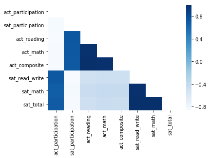

```python
corr = combined_2017_2018[["act_participation","sat_participation","act_reading", "act_math", "act_composite", "sat_read_write", "sat_math", "sat_total" ]].corr()

# Generate a mask for the upper triangle
mask = np.zeros_like(corr, dtype=np.bool)
mask[np.triu_indices_from(mask)] = True

sns.heatmap(corr,  mask = mask, cmap= "Blues")
```

#### Define a custom function to subplot histograms

[Helpful Link for Plotting Multiple Figures](https://matplotlib.org/users/pyplot_tutorial.html#working-with-multiple-figures-and-axes)

Here's some starter code:

```python
def subplot_histograms(dataframe, list_of_columns, list_of_titles, list_of_xlabels):
    nrows = int(np.ceil(len(list_of_columns)/2)) # Makes sure you have enough rows
    fig, ax = plt.subplots(nrows=nrows, ncols=2) # You'll want to specify your figsize
    ax = ax.ravel() # Ravel turns a matrix into a vector, which is easier to iterate
    for i, column in enumerate(list_of_columns): # Gives us an index value to get into all our lists
        ax[i].hist(dataframe[column]) # feel free to add more settings
        # Set titles, labels, etc here for each subplot
```

#### Plot and interpret histograms

For each of the following:

- Participation rates for SAT & ACT
- Math scores for SAT & ACT
- Reading/verbal scores for SAT & ACT

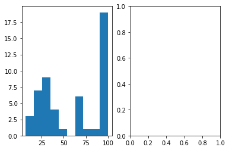

```python
# Code

subplot_histograms(combined_2017_2018[combined_2017_2018["year"]==2018][:], ["act_participation"], ["act_participation"], combined_2017_2018[(combined_2017_2018["year"]==2018)]["state"])

#combined_2017_2018[combined_2017_2018["Year"]==2018][:]
```

#### Plot and interpret scatter plots

For each of the following:

- SAT vs. ACT math scores for 2017
- SAT vs. ACT verbal/reading scores for 2017
- SAT vs. ACT total/composite scores for 2017
- Total scores for SAT 2017 vs. 2018
- Composite scores for ACT 2017 vs. 2018

Plot the two variables against each other using matplotlib or Seaborn

Your plots should show:

- Two clearly labeled axes
- A proper title
- Using colors and symbols that are clear and unmistakable

**Feel free to write a custom function, and subplot if you'd like.** Functions save both time and space.

```python
# Code
```

[output not shown]

#### Plot and interpret boxplots

For each numeric variable in the dataframe create a boxplot using Seaborn. Boxplots demonstrate central tendency and spread in variables. In a certain sense, these are somewhat redundant with histograms, but you may be better able to identify clear outliers or differences in IQR, etc.

Multiple values can be plotted to a single boxplot as long as they are of the same relative scale (meaning they have similar min/max values).

Each boxplot should:

- Only include variables of a similar scale
- Have clear labels for each variable
- Have appropriate titles and labels

## Descriptive and Inferential Statistics

#### We generally assuming that data we sample from a population will be normally distributed. Do we observe this trend?

##### Is it appropriate to compare *these* specific SAT and ACT math scores?

- ACT and SAT scores are impacted by overall participation of the respectives tests in the state.
- Additionally there will significant nuances not available within the aggregate state numbers.
- There are 51 data point data points so the sample will be statistically significant but the usage will depend completely in the manner the hypothesis is constructed.

```python
# Code:
```

## Outside Research

1. https://reports.collegeboard.org/pdf/2018-illinois-sat-suite-assessments-annual-report.pdf
2. https://reports.collegeboard.org/pdf/2017-illinois-sat-suite-assessments-annual-report.pdf
3. https://www.washingtonpost.com/education/2018/10/23/sat-reclaims-title-most-widely-used-college-admission-test/?noredirect=on&utm_term=.0eb856e63e8b
4. https://www.washingtonpost.com/news/grade-point/wp/2016/03/04/meet-the-man-behind-the-new-sat-im-in-the-anxiety-field/?utm_term=.da1ddae02cf8
5. https://www.washingtonpost.com/news/grade-point/wp/2016/03/04/meet-the-man-behind-the-new-sat-im-in-the-anxiety-field/?utm_term=.da1ddae02cf8
6. https://www.washingtonpost.com/news/grade-point/wp/2016/03/03/as-sat-enters-a-new-era-this-week-students-say-the-exam-has-improved/?utm_term=.ea7155320a7d

# Conclusions and Recommendations

**ACT States (SAT participation of less than 20%)**

- Focus on engaging the state level policy and decision makers:
- Correct the misconception that SAT is a narrow test for advanced kids.
- Focus on states with high participation for PSAT/ NMSQT.
- Structure deals and contracts to shift to SAT (e.g Colorado and Illinois)
- If shift to SAT is not possible then lobby to shift away from a mandated ACT only framework by focusing on the Straightforward and approach nature of the new SAT framework.

**Growing States (SAT Participation of 20-90%)**

- Improve institutional engagement efforts with school systems in these states to encourage them to switch to the SAT framework by highlighting
- The alignment of the test with the state and school curriculums
- The emphasis on core skills.
- Help the University admission officers to use reliable and valid results to do their job well.
- Enable schools to administer tests during school hours.

**Key States (More than 90% SAT participation rates)**

- Focus on deepening the existing institutional relationships.
- Emphasize availability of Practice tests and online free tutoring (Khan Academy*) to enhance test scores.
- Carry out further research on means to improve Test score.